# KDD PROJECT FINAL

## DATA LOADING

Read the data:

```r
loan <- read.csv("loan.csv", na.strings = c(" ",""))
```

[output not shown]

## VISUALIZATION AND EXPLORATION

Visualize the tables from remaining data ex: loan_amount, funded_amount, investor_funds

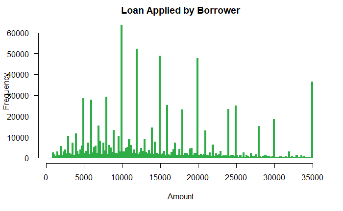

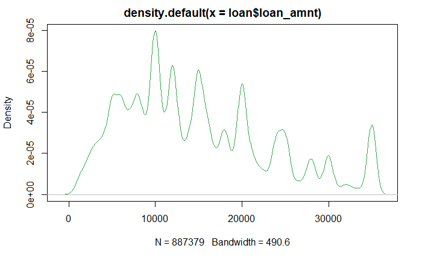

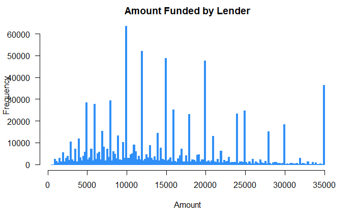

```r
hist(loan$loan_amnt, breaks=200, main="Loan Applied by Borrower", xlab="Amount", las=1, col='#2EAD46', border = "#2EAD46")
## or we can use density graph
plot(density(loan$loan_amnt), col='#2EAD46')


hist(loan$funded_amnt, breaks=200, main="Amount Funded by Lender", xlab="Amount", las=1, col='#2F8FF7', border = '#2F8FF7')
```

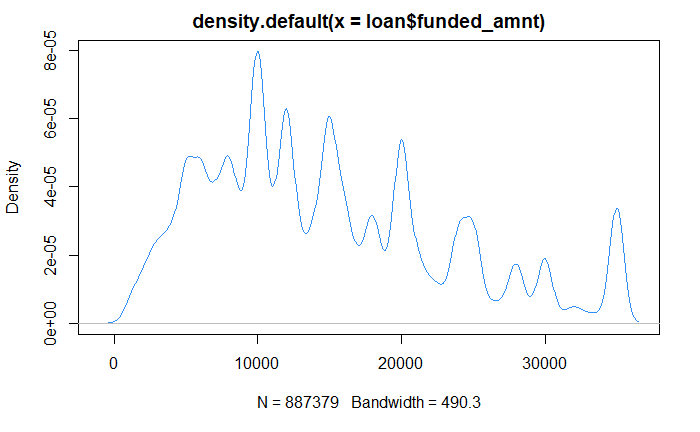

```r
plot(density(loan$funded_amnt), col='#2F8FF7')
```

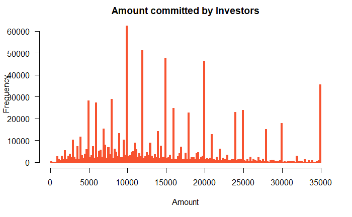

```r
hist(loan$funded_amnt_inv, breaks=200, main="Amount committed by Investors", xlab="Amount", las=1, col='#F7522F', border="#F7522F")
```

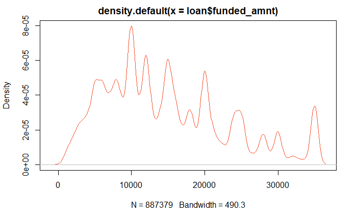

```r
plot(density(loan$funded_amnt), col='#F7522F')
```

Some Bar plots

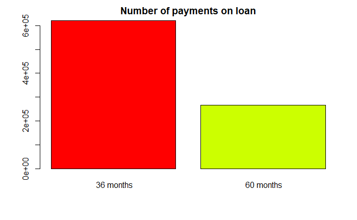

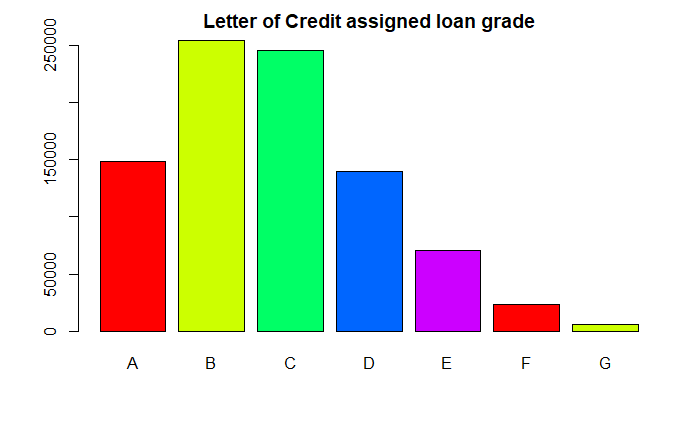

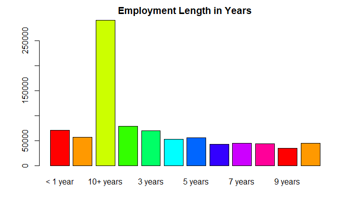

```r
plot(loan$term, col=rainbow(5), main="Number of payments on loan")
plot(loan$grade, col=rainbow(5), main="Letter of Credit assigned loan grade")

plot(loan$emp_length, col=rainbow(10), main="Employment Length in Years")
```

Some Box plots:

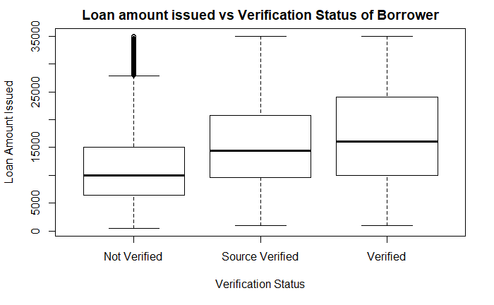

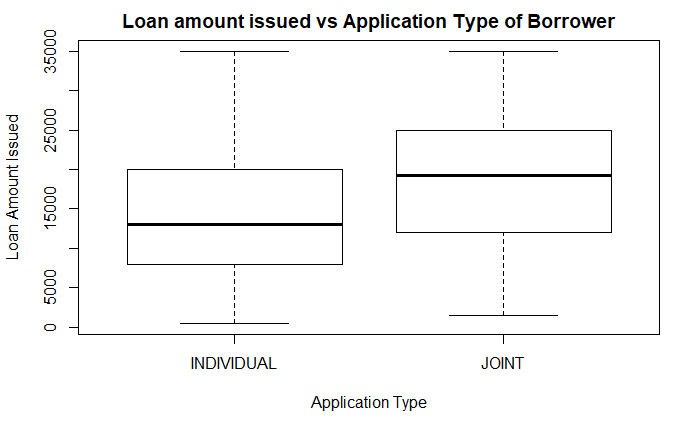

To generate Correlation Matrix: first extract matrix from sample data then feed it to the corrplot library

```r
install.packages('corrplot')
source("http://www.sthda.com/upload/rquery_cormat.r")
```

|  | total_acc | out_prncp | out_prncp_inv | installment | funded_amnt_inv | loan_amnt | funded_amnt | annual_inc | revol_bal | last_pymnt_amnt | total_rec_prncp | total_pymnt | total_pymnt_inv | dti | revol_util | int_rate | total_rec_int |
| --- | --- | --- | --- | --- | --- | --- | --- | --- | --- | --- | --- | --- | --- | --- | --- | --- | --- |
| total_acc | 1 |  |  |  |  |  |  |  |  |  |  |  |  |  |  |  |  |
| out_prncp | 0.14 | 1 |  |  |  |  |  |  |  |  |  |  |  |  |  |  |  |
| out_prncp_inv | 0.14 | 1 | 1 |  |  |  |  |  |  |  |  |  |  |  |  |  |  |
| installment | 0.2 | 0.55 | 0.55 | 1 |  |  |  |  |  |  |  |  |  |  |  |  |  |
| funded_amnt_inv | 0.22 | 0.65 | 0.65 | 0.94 | 1 |  |  |  |  |  |  |  |  |  |  |  |  |
| loan_amnt | 0.22 | 0.65 | 0.65 | 0.94 | 1 | 1 |  |  |  |  |  |  |  |  |  |  |  |
| funded_amnt | 0.22 | 0.65 | 0.65 | 0.95 | 1 | 1 | 1 |  |  |  |  |  |  |  |  |  |  |
| annual_inc | 0.19 | 0.21 | 0.21 | 0.33 | 0.33 | 0.33 | 0.33 | 1 |  |  |  |  |  |  |  |  |  |
| revol_bal | 0.19 | 0.23 | 0.23 | 0.32 | 0.33 | 0.33 | 0.33 | 0.3 | 1 |  |  |  |  |  |  |  |  |
| last_pymnt_amnt | 0.086 | -0.33 | -0.33 | 0.24 | 0.23 | 0.23 | 0.23 | 0.091 | 0.059 | 1 |  |  |  |  |  |  |  |

[output cut: 7 more lines]

|  | total_acc | out_prncp | out_prncp_inv | installment | funded_amnt_inv | loan_amnt | funded_amnt | annual_inc | revol_bal | last_pymnt_amnt | total_rec_prncp | total_pymnt | total_pymnt_inv | dti | revol_util | int_rate | total_rec_int |
| --- | --- | --- | --- | --- | --- | --- | --- | --- | --- | --- | --- | --- | --- | --- | --- | --- | --- |
| total_acc | 0 |  |  |  |  |  |  |  |  |  |  |  |  |  |  |  |  |
| out_prncp | 0 | 0 |  |  |  |  |  |  |  |  |  |  |  |  |  |  |  |
| out_prncp_inv | 0 | 0 | 0 |  |  |  |  |  |  |  |  |  |  |  |  |  |  |
| installment | 0 | 0 | 0 | 0 |  |  |  |  |  |  |  |  |  |  |  |  |  |
| funded_amnt_inv | 0 | 0 | 0 | 0 | 0 |  |  |  |  |  |  |  |  |  |  |  |  |
| loan_amnt | 0 | 0 | 0 | 0 | 0 | 0 |  |  |  |  |  |  |  |  |  |  |  |
| funded_amnt | 0 | 0 | 0 | 0 | 0 | 0 | 0 |  |  |  |  |  |  |  |  |  |  |
| annual_inc | 0 | 0 | 0 | 0 | 0 | 0 | 0 | 0 |  |  |  |  |  |  |  |  |  |
| revol_bal | 0 | 0 | 0 | 0 | 0 | 0 | 0 | 0 | 0 |  |  |  |  |  |  |  |  |
| last_pymnt_amnt | 0 | 0 | 0 | 0 | 0 | 0 | 0 | 0 | 0 | 0 |  |  |  |  |  |  |  |

[output cut: 7 more lines]

```
$sym
                total_acc out_prncp out_prncp_inv installment funded_amnt_inv loan_amnt funded_amnt
total_acc       1
out_prncp                 1
out_prncp_inv             1         1
installment               .         .             1
funded_amnt_inv           ,         ,             *           1
loan_amnt                 ,         ,             *           1               1
funded_amnt               ,         ,             *           1               1         1
annual_inc                                        .           .               .         .
revol_bal                                         .           .               .         .
last_pymnt_amnt           .         .
total_rec_prncp           .         .             .           .               .         .
total_pymnt                                       .           .               .         .
total_pymnt_inv                                   .           .               .         .
dti
revol_util
int_rate
total_rec_int                                     .           .               .         .
                annual_inc revol_bal last_pymnt_amnt total_rec_prncp total_pymnt total_pymnt_inv dti
total_acc
out_prncp
out_prncp_inv
installment
funded_amnt_inv
loan_amnt
funded_amnt
annual_inc      1
revol_bal                  1
last_pymnt_amnt                      1
total_rec_prncp                      ,               1
total_pymnt                          ,               B               1
total_pymnt_inv                      ,               B               1           1
dti                                                                                              1
revol_util
int_rate
total_rec_int                                        .               ,           ,
                revol_util int_rate total_rec_int
total_acc
out_prncp
out_prncp_inv
installment
funded_amnt_inv
loan_amnt
funded_amnt
annual_inc
revol_bal
last_pymnt_amnt
total_rec_prncp
total_pymnt
total_pymnt_inv
dti
revol_util      1
int_rate                   1
total_rec_int              .        1
attr(,"legend")
[1] 0 ‘ ’ 0.3 ‘.’ 0.6 ‘,’ 0.8 ‘+’ 0.9 ‘*’ 0.95 ‘B’ 1
```

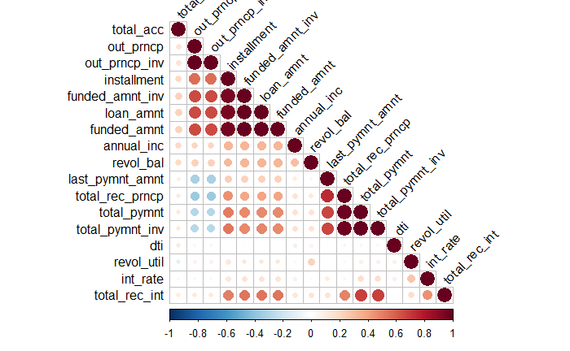

```r
cor_mat <- loan[,c('loan_amnt','funded_amnt','funded_amnt_inv','int_rate','installment','annual_inc','dti','revol_bal','revol_util','total_acc','out_prncp','out_prncp_inv','total_pymnt','total_pymnt_inv','total_rec_prncp','total_rec_int','last_pymnt_amnt')]

rquery.cormat(cor_mat)
```

## CLEANING:

```r
# Removing columns having more than 10% na values.
clean_loan <- loan[, -which(colMeans(is.na(loan)) > 0.1)]
dim(clean_loan)
```

```
[1] 887379     52
```

Removing irrelevant columns. ‘id’, ‘member_id’, ‘emp_title’, ‘url’, ‘zip_code’,‘policy_code’

```r
# match('url',names(clean_loan))
clean_loan = clean_loan[-c(1, 2, 11, 19, 22, 47)]
dim(clean_loan)
```

```
[1] 887379     46
```

We tried GLM and Linear Regression for multiple times using different set of attributes and finally came to the conclusion that following attributes needed to be removed which are not significant towards the goal.

Remove issue_d, title, addr_state, earliest_cr_line last_pymnt_d last_credit_pull_d

```r
clean_loan = clean_loan[-c(13, 17, 18, 21, 38, 40)]
dim(clean_loan)
```

```
[1] 887379     40
```

Clean any na values and check if there are any NA values present in it

```r
clean_loan = na.omit(clean_loan)
anyNA(clean_loan)
```

```
[1] FALSE
```

```r
dim(clean_loan)
```

```
[1] 816722     40
```

## PREPROCESSING:

Replace loan_status values with good or bad loans based on the labels in original loan_status

```r
dim(clean_loan)
```

```
[1] 816722     40
```

```r
str(clean_loan$loan_status)
```

```
 chr [1:816722] "good_loan" "good_loan" "good_loan" "good_loan" "good_loan" "good_loan" ...
```

| Nr | ColName | Class | NAs | Levels |
| --- | --- | --- | --- | --- |
| 1 | loan_amnt | numeric | . |  |
| 2 | funded_amnt | numeric | . |  |
| 3 | funded_amnt_inv | numeric | . |  |
| 4 | term | factor | . | (2): 1- 36 months, 2- 60 months |
| 5 | int_rate | numeric | . |  |
| 6 | installment | numeric | . |  |
| 7 | grade | factor | . | (7): 1-A, 2-B, 3-C, 4-D, 5-E, ... |
| 8 | sub_grade | factor | . | (35): 1-A1, 2-A2, 3-A3, 4-A4, 5-A5, ... |
| 9 | emp_length | factor | . | (12): 1-< 1 year, 2-1 year, 3-10+ years, 4-2 |
|  |  |  |  | years, 5-3 years, ... |

[output cut: 35 more lines]

```
-----------------------------------------------------------------------------------------------------
Describe clean_loan (data.frame):

data frame: 816722 obs. of  40 variables
        816722 complete cases (100.0%)



-----------------------------------------------------------------------------------------------------
1 - loan_amnt (numeric)

     length         n       NAs     unique         0s       mean     meanCI
    816'722   816'722         0      1'361          0  14'998.53  14'980.21
               100.0%      0.0%                  0.0%             15'016.85

        .05       .10       .25     median        .75        .90        .95
   3'900.00  5'000.00  8'400.00  13'500.00  20'000.00  28'000.00  32'125.00

      range        sd     vcoef        mad        IQR       skew       kurt
  34'000.00  8'446.32      0.56   8'747.34  11'600.00       0.66      -0.30

lowest : 1'000.0 (2'146), 1'025.0 (8), 1'050.0 (16), 1'075.0 (9), 1'100.0 (62)
highest: 34'900.0 (13), 34'925.0 (9), 34'950.0 (18), 34'975.0 (28), 35'000.0 (34'783)

heap(?): remarkable frequency (6.9%) for the mode (= 10000)

-----------------------------------------------------------------------------------------------------
2 - funded_amnt (numeric)

     length         n       NAs     unique         0s       mean     meanCI
    816'722   816'722         0      1'361          0  14'998.51  14'980.19
               100.0%      0.0%                  0.0%             15'016.83

        .05       .10       .25     median        .75        .90        .95
   3'900.00  5'000.00  8'400.00  13'500.00  20'000.00  28'000.00  32'125.00

      range        sd     vcoef        mad        IQR       skew       kurt
  34'000.00  8'446.30      0.56   8'747.34  11'600.00       0.66      -0.30

lowest : 1'000.0 (2'146), 1'025.0 (8), 1'050.0 (16), 1'075.0 (9), 1'100.0 (62)
highest: 34'900.0 (13), 34'925.0 (9), 34'950.0 (18), 34'975.0 (28), 35'000.0 (34'782)

heap(?): remarkable frequency (6.9%) for the mode (= 10000)
```

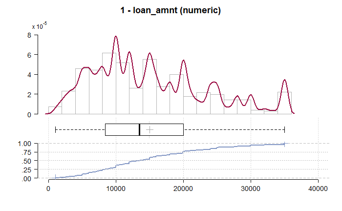

```
-----------------------------------------------------------------------------------------------------
3 - funded_amnt_inv (numeric)

     length         n       NAs     unique         0s       mean     meanCI
    816'722   816'722         0      1'402          0  14'992.19  14'973.88
               100.0%      0.0%                  0.0%             15'010.50

        .05       .10       .25     median        .75        .90        .95
   3'900.00  5'000.00  8'400.00  13'500.00  20'000.00  28'000.00  32'100.00

      range        sd     vcoef        mad        IQR       skew       kurt
  34'100.00  8'442.96      0.56   8'747.34  11'600.00       0.66      -0.30

lowest : 900.0, 925.0 (3), 950.0 (5), 975.0 (2), 1'000.0 (2'138)
highest: 34'900.0 (643), 34'925.0 (471), 34'950.0 (1'831), 34'975.0 (1'793), 35'000.0 (28'938)

heap(?): remarkable frequency (6.5%) for the mode (= 10000)
```

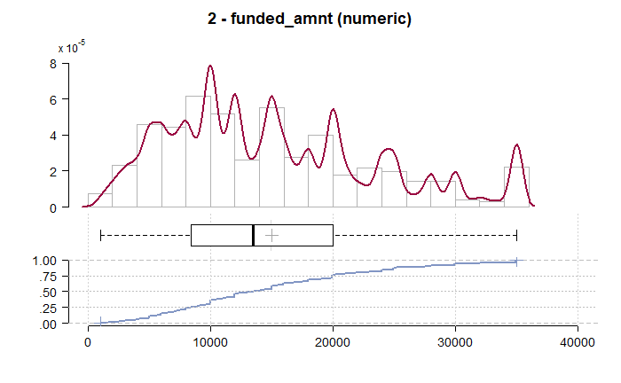

```
-----------------------------------------------------------------------------------------------------
4 - term (factor - dichotomous)

   length       n     NAs  unique
  816'722 816'722       0       2
           100.0%    0.0%

               freq   perc  lci.95  uci.95'
 36 months  566'768  69.4%   69.3%   69.5%
 60 months  249'954  30.6%   30.5%   30.7%

' 95%-CI Wilson
```

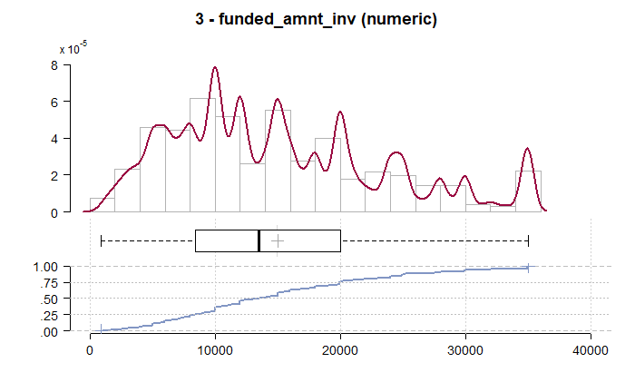

```
-----------------------------------------------------------------------------------------------------
5 - int_rate (numeric)

   length        n    NAs  unique     0s   mean  meanCI
  816'722  816'722      0     199      0  13.30   13.29
            100.0%   0.0%           0.0%          13.31

      .05      .10    .25  median    .75    .90     .95
     6.68     7.69   9.99   12.99  16.29  19.05   21.00

    range       sd  vcoef     mad    IQR   skew    kurt
    23.67     4.41   0.33    4.45   6.30   0.43   -0.16

lowest : 5.32 (9'651), 5.93 (1'812), 6.0 (97), 6.03 (9'272), 6.24 (7'470)
highest: 27.49 (7), 27.88 (222), 27.99 (5), 28.49 (139), 28.99 (112)
```

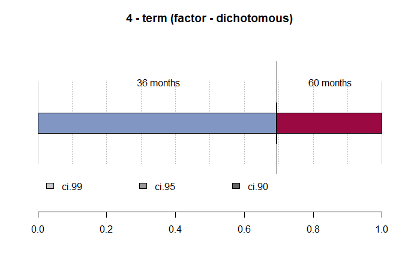

```
-----------------------------------------------------------------------------------------------------
6 - installment (numeric)

    length        n     NAs  unique      0s    mean  meanCI
   816'722  816'722       0  63'166       0  443.52  442.99
             100.0%    0.0%            0.0%          444.05

       .05      .10     .25  median     .75     .90     .95
    128.16   170.12  266.83  388.11  580.73  785.62  916.56

     range       sd   vcoef     mad     IQR    skew    kurt
  1'422.20   244.31    0.55  216.01  313.90    0.93    0.66

lowest : 23.26, 23.36, 25.81, 25.86, 27.85
highest: 1'407.01 (8), 1'408.13 (5), 1'409.99 (3), 1'424.57 (2), 1'445.46 (2)
```

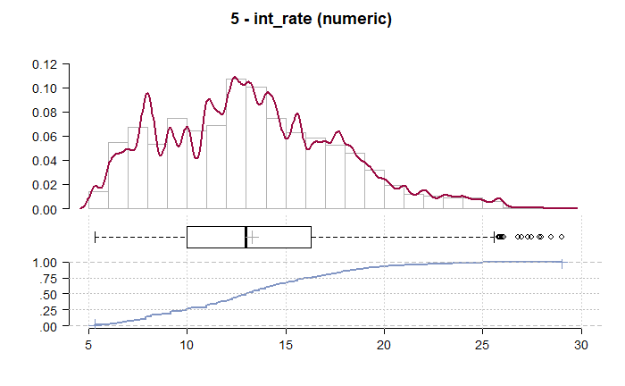

```
-----------------------------------------------------------------------------------------------------
7 - grade (factor)

   length       n     NAs  unique  levels   dupes
  816'722 816'722       0       7       7       y
           100.0%    0.0%
```

| level | freq | perc | cumfreq | cumperc |
| --- | --- | --- | --- | --- |
| B | 232'674 | 28.5% | 232'674 | 28.5% |
| C | 231'207 | 28.3% | 463'881 | 56.8% |
| A | 131'428 | 16.1% | 595'309 | 72.9% |
| D | 129'860 | 15.9% | 725'169 | 88.8% |
| E | 65'646 | 8.0% | 790'815 | 96.8% |
| F | 21'085 | 2.6% | 811'900 | 99.4% |
| G | 4'822 | 0.6% | 816'722 | 100.0% |

```
NANANA
```

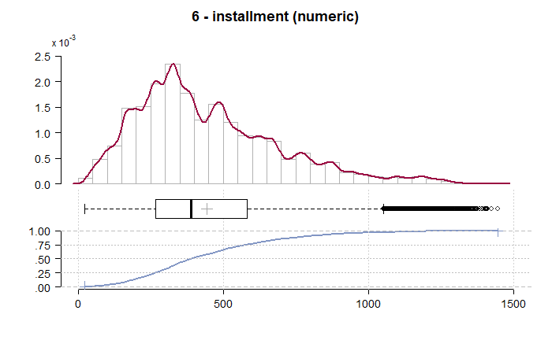

```
-----------------------------------------------------------------------------------------------------
8 - sub_grade (factor)

   length       n     NAs  unique  levels   dupes
  816'722 816'722       0      35      35       y
           100.0%    0.0%
```

| level | freq | perc | cumfreq | cumperc |
| --- | --- | --- | --- | --- |
| B4 | 51'149 | 6.3% | 51'149 | 6.3% |
| B3 | 50'539 | 6.2% | 101'688 | 12.5% |
| C1 | 49'245 | 6.0% | 150'933 | 18.5% |
| C2 | 48'376 | 5.9% | 199'309 | 24.4% |
| C3 | 47'711 | 5.8% | 247'020 | 30.2% |
| C4 | 46'681 | 5.7% | 293'701 | 36.0% |
| B2 | 45'073 | 5.5% | 338'774 | 41.5% |
| B5 | 44'213 | 5.4% | 382'987 | 46.9% |
| B1 | 41'700 | 5.1% | 424'687 | 52.0% |
| A5 | 40'559 | 5.0% | 465'246 | 57.0% |

[output cut: 2 more lines]

```
... etc.
 [list output truncated]
```

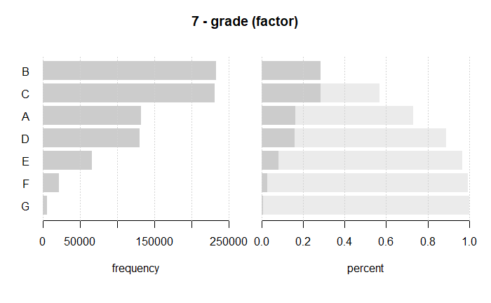

```
-----------------------------------------------------------------------------------------------------
9 - emp_length (factor)

   length       n     NAs  unique  levels   dupes
  816'722 816'722       0      12      12       y
           100.0%    0.0%
```

| level | freq | perc | cumfreq | cumperc |
| --- | --- | --- | --- | --- |
| 10+ years | 274'533 | 33.6% | 274'533 | 33.6% |
| 2 years | 71'501 | 8.8% | 346'034 | 42.4% |
| 3 years | 63'580 | 7.8% | 409'614 | 50.2% |
| < 1 year | 63'158 | 7.7% | 472'772 | 57.9% |
| 1 year | 51'537 | 6.3% | 524'309 | 64.2% |
| 5 years | 49'760 | 6.1% | 574'069 | 70.3% |
| 4 years | 46'663 | 5.7% | 620'732 | 76.0% |
| n/a | 42'754 | 5.2% | 663'486 | 81.2% |
| 7 years | 41'178 | 5.0% | 704'664 | 86.3% |
| 8 years | 41'165 | 5.0% | 745'829 | 91.3% |

[output cut: 2 more lines]

```
NANANA
```

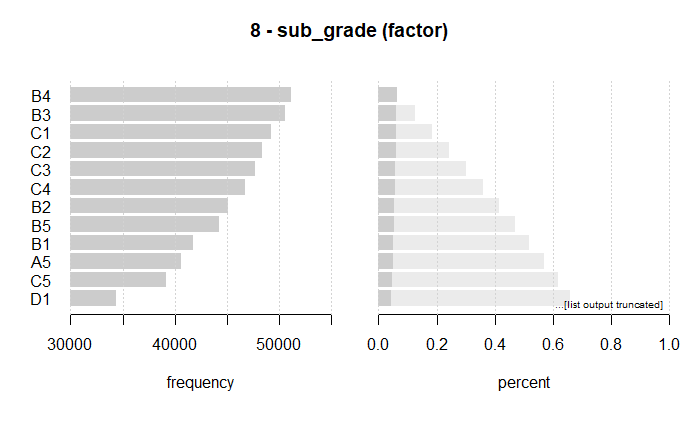

```
-----------------------------------------------------------------------------------------------------
10 - home_ownership (factor)

   length       n     NAs  unique  levels   dupes
  816'722 816'722       0       6       6       y
           100.0%    0.0%
```

| level | freq | perc | cumfreq | cumperc |
| --- | --- | --- | --- | --- |
| MORTGAGE | 412'127 | 50.5% | 412'127 | 50.5% |
| RENT | 322'515 | 39.5% | 734'642 | 90.0% |
| OWN | 81'990 | 10.0% | 816'632 | 100.0% |
| OTHER | 45 | 0.0% | 816'677 | 100.0% |
| NONE | 42 | 0.0% | 816'719 | 100.0% |
| ANY | 3 | 0.0% | 816'722 | 100.0% |

```
NANANA
```

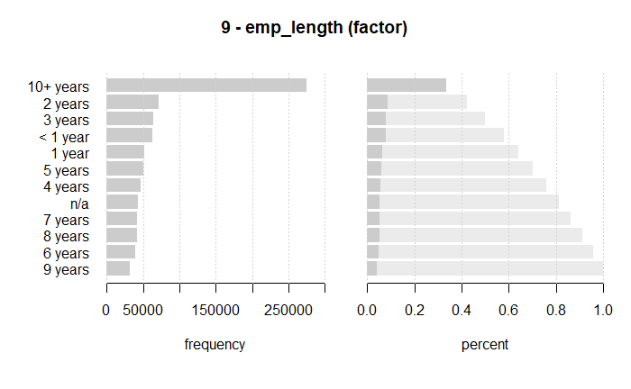

```
-----------------------------------------------------------------------------------------------------
11 - annual_inc (numeric)

        length          n        NAs     unique         0s        mean      meanCI
       816'722    816'722          0     46'250          2   75'544.91   75'403.27
                   100.0%       0.0%                  0.0%               75'686.54

           .05        .10        .25     median        .75         .90         .95
     28'800.00  35'000.00  46'000.00  65'000.00  90'000.00  125'000.00  150'000.00

         range         sd      vcoef        mad        IQR        skew        kurt
  9'500'000.00  65'307.99       0.86  30'393.30  44'000.00       45.51    4'928.21

lowest : 0.0 (2), 1'200.0, 1'770.0, 3'000.0 (2), 3'600.0
highest: 8'700'000.0, 8'706'582.0, 8'900'060.0, 9'000'000.0, 9'500'000.0
```

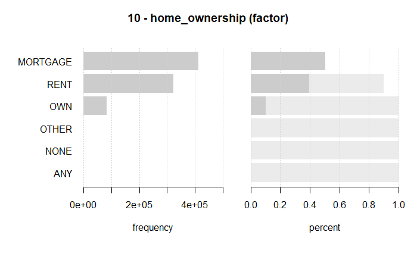

```
-----------------------------------------------------------------------------------------------------
12 - verification_status (factor)

   length       n     NAs  unique  levels   dupes
  816'722 816'722       0       3       3       y
           100.0%    0.0%
```

| level | freq | perc | cumfreq | cumperc |
| --- | --- | --- | --- | --- |
| Source Verified | 311'572 | 38.1% | 311'572 | 38.1% |
| Verified | 267'370 | 32.7% | 578'942 | 70.9% |
| Not Verified | 237'780 | 29.1% | 816'722 | 100.0% |

```
NANANA
```

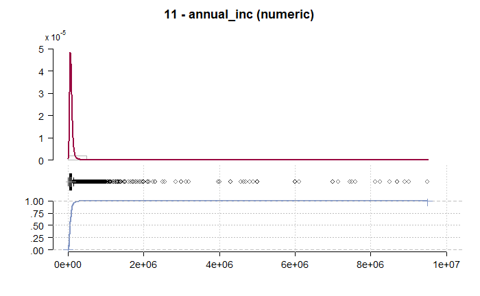

```
-----------------------------------------------------------------------------------------------------
13 - loan_status (character - dichotomous)

   length       n     NAs  unique
  816'722 816'722       0       2
           100.0%    0.0%

              freq   perc  lci.95  uci.95'
good_loan  760'341  93.1%   93.0%   93.2%
bad_loan    56'381   6.9%    6.8%    7.0%

' 95%-CI Wilson
```

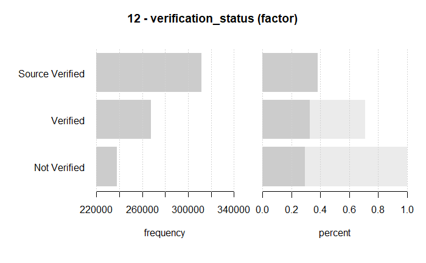

```
-----------------------------------------------------------------------------------------------------
14 - pymnt_plan (factor - dichotomous)

   length       n     NAs  unique
  816'722 816'722       0       2
           100.0%    0.0%

      freq    perc  lci.95  uci.95'
n  816'716  100.0%  100.0%  100.0%
y        6    0.0%    0.0%    0.0%

' 95%-CI Wilson
```

[28 more figures not shown]

```r
DescTools::Desc(clean_loan)
```

## BALANCED RESAMPLING FOR TRAINING AND TESTING

We found out that LOAN_STATUS, which we are taking as Response Variable, is highly unbalanced if we take the whole dataset. Hence we decided to resample the dataset.

Now we have balanced Loan Status in subsample with as max as possible records.

```
-----------------------------------------------------------------------------------------------------
sample$loan_status (factor - dichotomous)

   length       n     NAs  unique
  112'762 112'762       0       2
           100.0%    0.0%

             freq   perc  lci.95  uci.95'
bad_loan   56'381  50.0%   49.7%   50.3%
good_loan  56'381  50.0%   49.7%   50.3%

' 95%-CI Wilson
```

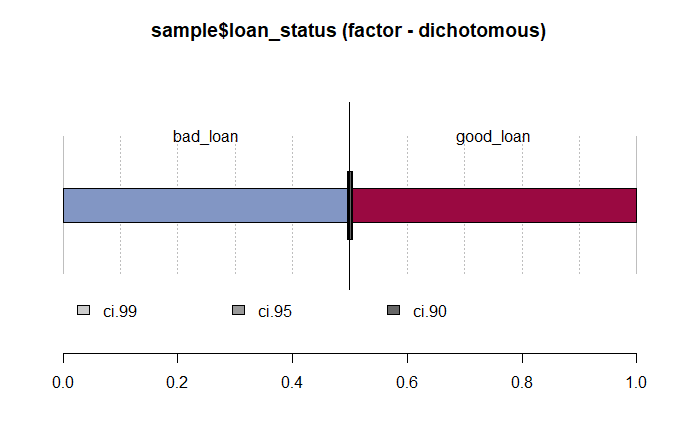

```r
DescTools::Desc(sample$loan_status)
```

Final Structure of Sample Dataset:

```r
str(sample)
```

```
'data.frame':   112762 obs. of  40 variables:
 $ loan_amnt                 : num  25000 6400 10000 10050 10000 ...
 $ funded_amnt               : num  25000 6400 10000 10050 10000 ...
 $ funded_amnt_inv           : num  25000 6400 10000 10050 9950 ...
 $ term                      : Factor w/ 2 levels " 36 months"," 60 months": 2 1 1 1 1 1 1 1 1 1 ...
 $ int_rate                  : num  15.61 11.99 9.17 17.27 9.99 ...
 $ installment               : num  603 213 319 360 323 ...
 $ grade                     : Factor w/ 7 levels "A","B","C","D",..: 3 2 2 3 2 3 1 6 2 2 ...
 $ sub_grade                 : Factor w/ 35 levels "A1","A2","A3",..: 15 8 6 15 8 11 5 26 6 6 ...
 $ emp_length                : Factor w/ 12 levels "< 1 year","1 year",..: 4 10 3 7 3 3 3 9 1 3 ...
 $ home_ownership            : Factor w/ 6 levels "ANY","MORTGAGE",..: 2 2 2 5 6 2 2 2 6 6 ...
 $ annual_inc                : num  300000 65000 75000 30000 110000 ...
 $ verification_status       : Factor w/ 3 levels "Not Verified",..: 2 1 1 3 2 3 1 3 2 1 ...
 $ loan_status               : Factor w/ 2 levels "bad_loan","good_loan": 1 2 2 1 2 1 2 1 2 2 ...
 $ pymnt_plan                : Factor w/ 2 levels "n","y": 1 1 1 1 1 1 1 1 1 1 ...
```

[output cut: 28 more lines]

Now create training and testing data sets in 70:30 ratio

```r
dim(sample_train)
```

```
[1] 78933    40
```

```r
dim(sample_test)
```

```
[1] 33829    40
```

Balanced Class in training and testing data set as well.

```
-----------------------------------------------------------------------------------------------------
sample_train$loan_status (factor - dichotomous)

  length      n    NAs unique
  78'933 78'933      0      2
         100.0%   0.0%

             freq   perc  lci.95  uci.95'
bad_loan   39'571  50.1%   49.8%   50.5%
good_loan  39'362  49.9%   49.5%   50.2%

' 95%-CI Wilson
```

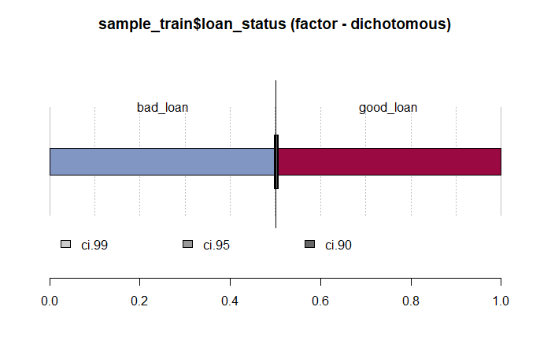

```r
DescTools::Desc(sample_train$loan_status)
```

```
-----------------------------------------------------------------------------------------------------
sample_test$loan_status (factor - dichotomous)

  length      n    NAs unique
  33'829 33'829      0      2
         100.0%   0.0%

             freq   perc  lci.95  uci.95'
bad_loan   16'810  49.7%   49.2%   50.2%
good_loan  17'019  50.3%   49.8%   50.8%

' 95%-CI Wilson
```

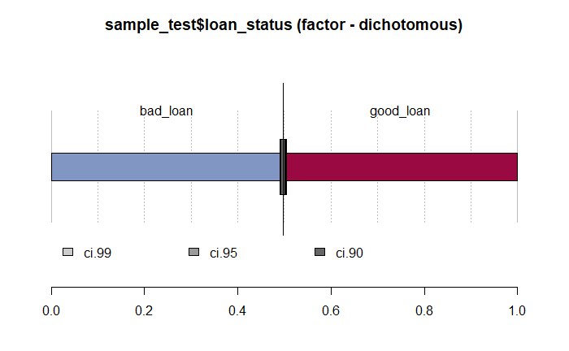

```r
DescTools::Desc(sample_test$loan_status)
```

## TRAINING and TESTING THE MODELS

# 1) DECISION TREE

```r
set.seed(100)
tree_model = rpart(loan_status~., data=sample_train[,-c(27,34)], method ="class")

summary(tree_model)
```

```
Call:
rpart(formula = loan_status ~ ., data = sample_train[, -c(27,
    34)], method = "class")
  n= 78933

          CP nsplit rel error    xerror        xstd
1 0.41814440      0 1.0000000 1.0000000 0.003568787
2 0.10924242      1 0.5818556 0.5819318 0.003239417
3 0.01986688      2 0.4726132 0.4726386 0.003029422
4 0.01714852      3 0.4527463 0.4527717 0.002984224
5 0.01415070      5 0.4184493 0.4188812 0.002901525
6 0.01000000      7 0.3901479 0.3907068 0.002827021

Variable importance
        total_rec_prncp               out_prncp           out_prncp_inv         total_pymnt_inv
                     18                      16                      16                      12
             recoveries collection_recovery_fee                int_rate               sub_grade
                      8                       8                       3                       3
                  grade             installment             funded_amnt               loan_amnt
                      2                       2                       2                       2
        funded_amnt_inv           total_rec_int      total_rec_late_fee                    term
                      2                       2                       2                       1

Node number 1: 78933 observations,    complexity param=0.4181444
  predicted class=bad_loan   expected loss=0.4986761  P(node) =1
    class counts: 39571 39362
   probabilities: 0.501 0.499
  left son=2 (32602 obs) right son=3 (46331 obs)
  Primary splits:
      out_prncp               < 67.88    to the left,  improve=7184.053, (0 missing)
      out_prncp_inv           < 67.88    to the left,  improve=7184.053, (0 missing)
      recoveries              < 3.555    to the right, improve=6804.300, (0 missing)
      collection_recovery_fee < 0.03555  to the right, improve=6612.699, (0 missing)
      int_rate                < 12.77    to the right, improve=3678.849, (0 missing)
  Surrogate splits:
      out_prncp_inv           < 67.88    to the left,  agree=1.000, adj=1.000, (0 split)
      recoveries              < 3.555    to the right, agree=0.735, adj=0.358, (0 split)
      collection_recovery_fee < 0.03555  to the right, agree=0.731, adj=0.349, (0 split)
      total_rec_prncp         < 9999.665 to the right, agree=0.625, adj=0.093, (0 split)
      total_pymnt_inv         < 9460.695 to the right, agree=0.621, adj=0.081, (0 split)
```

[output cut: 127 more lines]

```

Node number 13: 24885 observations
  predicted class=good_loan  expected loss=0.4007635  P(node) =0.3152674
    class counts:  9973 14912
   probabilities: 0.401 0.599

Node number 18: 5160 observations
  predicted class=bad_loan   expected loss=0.07112403  P(node) =0.0653719
    class counts:  4793   367
   probabilities: 0.929 0.071

Node number 19: 1888 observations
  predicted class=good_loan  expected loss=0.1424788  P(node) =0.02391902
    class counts:   269  1619
   probabilities: 0.142 0.858
```

```r
printcp(tree_model)
```

```
Classification tree:
rpart(formula = loan_status ~ ., data = sample_train[, -c(27,
    34)], method = "class")

Variables actually used in tree construction:
[1] int_rate           loan_amnt          out_prncp          recoveries         total_rec_late_fee
[6] total_rec_prncp

Root node error: 39362/78933 = 0.49868

n= 78933

        CP nsplit rel error  xerror      xstd
1 0.418144      0   1.00000 1.00000 0.0035688
2 0.109242      1   0.58186 0.58191 0.0032394
3 0.019867      2   0.47261 0.47264 0.0030294
4 0.017149      3   0.45275 0.45277 0.0029842
5 0.014151      5   0.41845 0.41959 0.0029033
6 0.010000      7   0.39015 0.39132 0.0028287
```

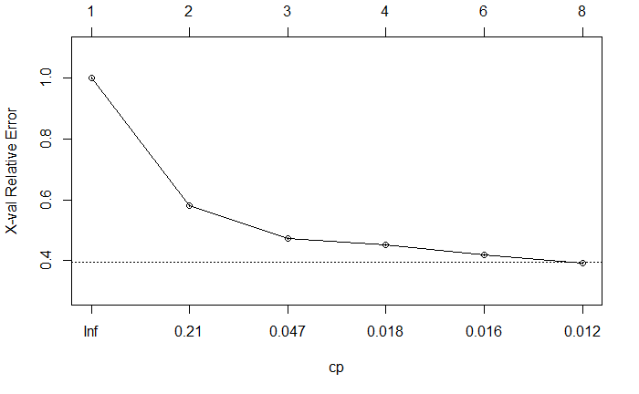

```r
plotcp(tree_model)
```

The value of cp should be least, so that the cross-validated error rate is minimum.

[output not shown]

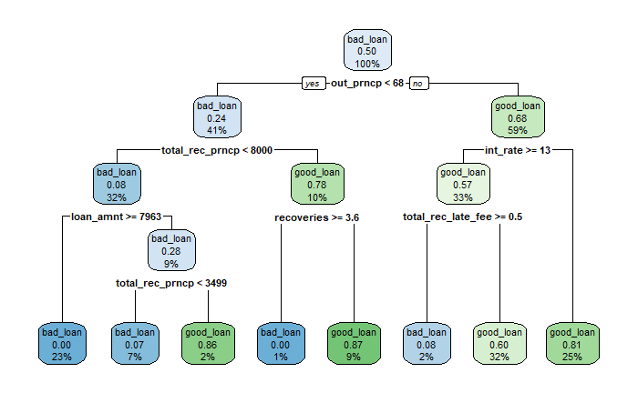

```r
rpart.plot(tree_model)
```

```r
tree_model$variable.importance
```

```
        total_rec_prncp               out_prncp           out_prncp_inv         total_pymnt_inv
           8132.6376112            7184.0532473            7184.0532473            5421.6787623
             recoveries collection_recovery_fee                int_rate               sub_grade
           3634.1688160            3528.6757125            1478.8494300            1263.9590748
                  grade             installment             funded_amnt               loan_amnt
           1088.8722948             813.6871773             798.5585484             798.5585484
        funded_amnt_inv           total_rec_int      total_rec_late_fee                    term
            796.5190969             706.7835065             679.6623146             229.0231688
    verification_status              annual_inc              revol_util
            149.3486335              97.1005499               0.5082125
```

```r
set.seed(100)
tree_pred = predict(tree_model,sample_test, type = "class")
with(sample_test, table(loan_status, tree_pred))
```

```
           tree_pred
loan_status bad_loan good_loan
  bad_loan     10588      6222
  good_loan      205     16814
```

Performance of Decision Tree:

| ACCURACY | SENSITIVITY | SPECIFICITY |
| --- | --- | --- |
| 81.002 | 62.986 | 98.795 |

# RANDOM FOREST

```r
summary(rf_model)
```

```
                Length Class  Mode
call                 4 -none- call
type                 1 -none- character
predicted        78933 factor numeric
err.rate           300 -none- numeric
confusion            6 -none- numeric
votes           157866 matrix numeric
oob.times        78933 -none- numeric
classes              2 -none- character
importance          39 -none- numeric
importanceSD         0 -none- NULL
localImportance      0 -none- NULL
proximity            0 -none- NULL
ntree                1 -none- numeric
mtry                 1 -none- numeric
forest              14 -none- list
y                78933 factor numeric
test                 0 -none- NULL
inbag                0 -none- NULL
terms                3 terms  call
```

```r
str(rf_model)
```

```
List of 19
 $ call           : language randomForest(formula = loan_status ~ ., data = sample_train, ntree = 100)
 $ type           : chr "classification"
 $ predicted      : Factor w/ 2 levels "bad_loan","good_loan": 1 2 2 1 1 2 1 1 1 1 ...
  ..- attr(*, "names")= chr [1:78933] "848812" "64220" "378022" "155685" ...
 $ err.rate       : num [1:100, 1:3] 0.219 0.223 0.222 0.22 0.217 ...
  ..- attr(*, "dimnames")=List of 2
  .. ..$ : NULL
  .. ..$ : chr [1:3] "OOB" "bad_loan" "good_loan"
 $ confusion      : num [1:2, 1:3] 2.90e+04 2.77e+03 1.06e+04 3.66e+04 2.67e-01 ...
  ..- attr(*, "dimnames")=List of 2
  .. ..$ : chr [1:2] "bad_loan" "good_loan"
  .. ..$ : chr [1:3] "bad_loan" "good_loan" "class.error"
 $ votes          : 'matrix' num [1:78933, 1:2] 0.6774 0.0526 0.1429 1 1 ...
  ..- attr(*, "dimnames")=List of 2
  .. ..$ : chr [1:78933] "848812" "64220" "378022" "155685" ...
  .. ..$ : chr [1:2] "bad_loan" "good_loan"
 $ oob.times      : num [1:78933] 31 38 35 38 39 35 42 44 45 46 ...
 $ classes        : chr [1:2] "bad_loan" "good_loan"
 $ importance     : num [1:39, 1] 736.4 640.4 737.7 97.7 1428.2 ...
  ..- attr(*, "dimnames")=List of 2
  .. ..$ : chr [1:39] "loan_amnt" "funded_amnt" "funded_amnt_inv" "term" ...
  .. ..$ : chr "MeanDecreaseGini"
 $ importanceSD   : NULL
 $ localImportance: NULL
 $ proximity      : NULL
 $ ntree          : num 100
 $ mtry           : num 6
 $ forest         :List of 14
  ..$ ndbigtree : int [1:100] 14277 14571 14495 14215 14437 14695 14877 14517 14597 15165 ...
  ..$ nodestatus: int [1:15609, 1:100] 1 1 1 1 1 1 1 1 1 1 ...
  ..$ bestvar   : int [1:15609, 1:100] 28 33 33 25 1 32 25 32 5 32 ...
  ..$ treemap   : int [1:15609, 1:2, 1:100] 2 4 6 8 10 12 14 16 18 20 ...
  ..$ nodepred  : int [1:15609, 1:100] 0 0 0 0 0 0 0 0 0 0 ...
  ..$ xbestsplit: num [1:15609, 1:100] 9998.75 2161.72 2650.93 6.79 12787.5 ...
  ..$ pid       : num [1:2] 1 1
  ..$ cutoff    : num [1:2] 0.5 0.5
  ..$ ncat      : Named int [1:39] 1 1 1 2 1 1 7 35 12 6 ...
  .. ..- attr(*, "names")= chr [1:39] "loan_amnt" "funded_amnt" "funded_amnt_inv" "term" ...
  ..$ maxcat    : int 35
```

[output cut: 47 more lines]

```
 $ terms          :Classes 'terms', 'formula'  language loan_status ~ loan_amnt + funded_amnt + funded_amnt_inv + term + int_rate + installment + grade +      sub_grade | __truncated__ ...
  .. ..- attr(*, "variables")= language list(loan_status, loan_amnt, funded_amnt, funded_amnt_inv, term, int_rate, installment, grade,      sub_grade, em| __truncated__ ...
  .. ..- attr(*, "factors")= int [1:40, 1:39] 0 1 0 0 0 0 0 0 0 0 ...
  .. .. ..- attr(*, "dimnames")=List of 2
  .. .. .. ..$ : chr [1:40] "loan_status" "loan_amnt" "funded_amnt" "funded_amnt_inv" ...
  .. .. .. ..$ : chr [1:39] "loan_amnt" "funded_amnt" "funded_amnt_inv" "term" ...
  .. ..- attr(*, "term.labels")= chr [1:39] "loan_amnt" "funded_amnt" "funded_amnt_inv" "term" ...
  .. ..- attr(*, "order")= int [1:39] 1 1 1 1 1 1 1 1 1 1 ...
  .. ..- attr(*, "intercept")= num 0
  .. ..- attr(*, "response")= int 1
  .. ..- attr(*, ".Environment")=<environment: R_GlobalEnv>
  .. ..- attr(*, "predvars")= language list(loan_status, loan_amnt, funded_amnt, funded_amnt_inv, term, int_rate, installment, grade,      sub_grade, em| __truncated__ ...
  .. ..- attr(*, "dataClasses")= Named chr [1:40] "factor" "numeric" "numeric" "numeric" ...
  .. .. ..- attr(*, "names")= chr [1:40] "loan_status" "loan_amnt" "funded_amnt" "funded_amnt_inv" ...
 - attr(*, "class")= chr [1:2] "randomForest.formula" "randomForest"
```

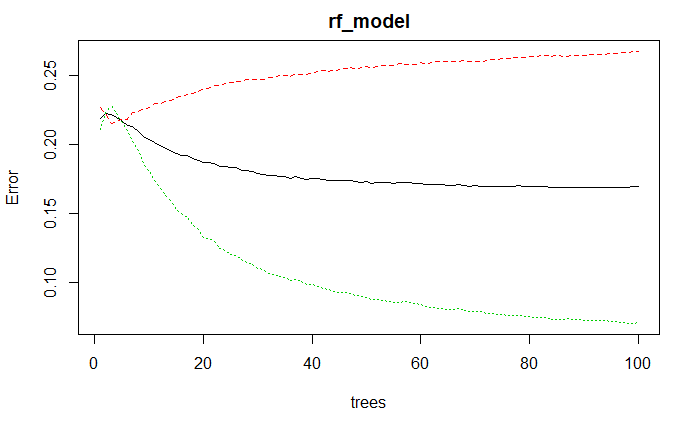

```r
plot(rf_model)
```

Importance of Predictors

```r
importance(rf_model,type = 2)
```

```
                           MeanDecreaseGini
loan_amnt                      7.364377e+02
funded_amnt                    6.404176e+02
funded_amnt_inv                7.377123e+02
term                           9.769511e+01
int_rate                       1.428198e+03
installment                    9.485848e+02
grade                          7.106866e+02
sub_grade                      1.436056e+03
emp_length                     1.271576e+03
home_ownership                 2.198949e+02
annual_inc                     7.790307e+02
verification_status            2.485465e+02
pymnt_plan                     7.225539e-02
purpose                        4.826107e+02
dti                            8.642775e+02
delinq_2yrs                    1.988950e+02
inq_last_6mths                 2.823931e+02
open_acc                       5.939489e+02
pub_rec                        1.298017e+02
revol_bal                      8.631693e+02
revol_util                     8.559598e+02
total_acc                      7.058403e+02
initial_list_status            1.737956e+02
out_prncp                      3.875468e+03
out_prncp_inv                  4.261617e+03
total_pymnt                    1.761235e+03
total_pymnt_inv                1.907669e+03
total_rec_prncp                2.489460e+03
total_rec_int                  1.179032e+03
total_rec_late_fee             1.005612e+03
recoveries                     1.695102e+03
collection_recovery_fee        1.192930e+03
last_pymnt_amnt                3.712070e+03
collections_12_mths_ex_med     2.543338e+01
application_type               7.479678e-01
acc_now_delinq                 1.422156e+01
tot_coll_amt                   2.099423e+02
tot_cur_bal                    8.438740e+02
total_rev_hi_lim               8.798487e+02
```

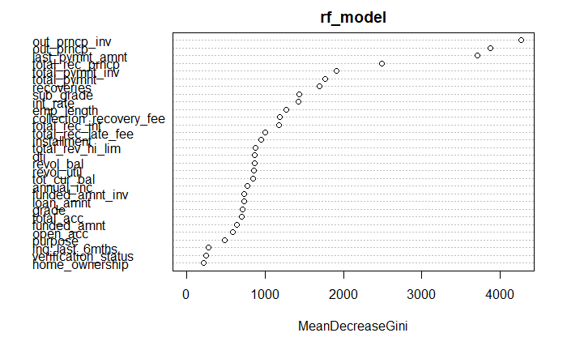

```r
varImpPlot(rf_model)
```

Performance of RF Model:

```r
with(sample_test, table(loan_status, fr_pred))
```

```
           fr_pred
loan_status bad_loan good_loan
  bad_loan     12288      4522
  good_loan      960     16059
```

Performance of Random Forest:

| ACCURACY | SENSITIVITY | SPECIFICITY |
| --- | --- | --- |
| 83.795 | 73.099 | 94.359 |

Cross validation of RF:

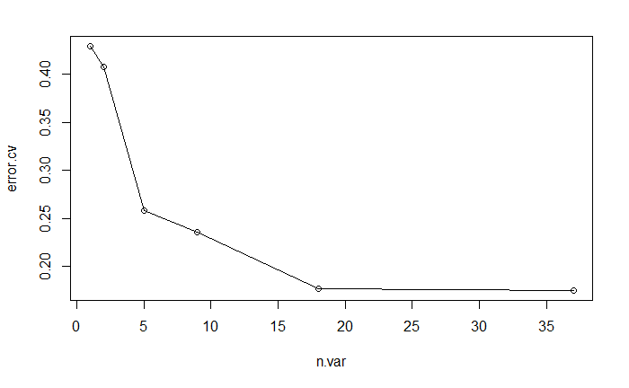